# Project 1

My main interest in to explore the most common auther and his sentences in the dataset. Relating areas of articles to explore may have: the key words of contents, the most common ending punctuation and the sentence length analysis, the relationship between of the original publcation date and the corpus publication date.

```r
library(dplyr)
library(ds4psy)
```

```r
library(ggplot2)
setwd("C:\\Users\\tuyum\\Desktop\\study\\Columbia\\Applied DS")
data<-read.csv("philosophy_data.csv")
summary(data)
```

```
##     title              author             school          sentence_spacy
##  Length:360808      Length:360808      Length:360808      Length:360808
##  Class :character   Class :character   Class :character   Class :character
##  Mode  :character   Mode  :character   Mode  :character   Mode  :character
##
##
##
##  sentence_str       original_publication_date corpus_edition_date
##  Length:360808      Min.   :-350              Min.   :1887
##  Class :character   1st Qu.:1641              1st Qu.:1991
##  Mode  :character   Median :1817              Median :2001
##                     Mean   :1327              Mean   :1995
##                     3rd Qu.:1949              3rd Qu.:2007
##                     Max.   :1985              Max.   :2016
##  sentence_length  sentence_lowered   tokenized_txt      lemmatized_str
##  Min.   :  20.0   Length:360808      Length:360808      Length:360808
##  1st Qu.:  75.0   Class :character   Class :character   Class :character
##  Median : 127.0   Mode  :character   Mode  :character   Mode  :character
##  Mean   : 150.8
##  3rd Qu.: 199.0
##  Max.   :2649.0
```

From the summary, we can take a glance at the distribution of original publication date, corpus edition date and sentence length. By looking at the min, max, mean, we can have a general idea of the range and frequency.

```r
glimpse(data)
```

```
## Rows: 360,808
## Columns: 11
## $ title                     <chr> "Plato - Complete Works", "Plato - Comple...
## $ author                    <chr> "Plato", "Plato", "Plato", "Plato", "Plat...
## $ school                    <chr> "plato", "plato", "plato", "plato", "plat...
## $ sentence_spacy            <chr> " What's new, Socrates, to make you leave...
## $ sentence_str              <chr> " What's new, Socrates, to make you leave...
## $ original_publication_date <int> -350, -350, -350, -350, -350, -350, -350,...
## $ corpus_edition_date       <int> 1997, 1997, 1997, 1997, 1997, 1997, 1997,...
## $ sentence_length           <int> 125, 69, 74, 21, 101, 34, 43, 35, 33, 147...
## $ sentence_lowered          <chr> " what's new, socrates, to make you leave...
## $ tokenized_txt             <chr> "['what', 'new', 'socrates', 'to', 'make'...
## $ lemmatized_str            <chr> "   what be new , Socrates , to make -PRO...
```

I

```r
table(data$author)
```

```
##
##       Aristotle        Beauvoir        Berkeley           Davis         Deleuze
##           48779           13017            2734            3059           12540
##         Derrida       Descartes       Epictetus          Fichte        Foucault
##            5999            1132             323            5308           15240
##           Hegel       Heidegger            Hume         Husserl            Kant
##           22700           15239            8312            5742           14128
##          Keynes          Kripke         Leibniz           Lenin           Lewis
##            3411           12479            5027            4469           13120
##           Locke     Malebranche Marcus Aurelius            Marx   Merleau-Ponty
##            8885           12997            2212           13489            7592
##           Moore       Nietzsche           Plato          Popper           Quine
##            3668           13548           38366            4678            7373
##         Ricardo         Russell           Smith         Spinoza    Wittgenstein
##            3090            5073           11693            3793            9034
##  Wollstonecraft
##            2559
```

II

```r
Subset<-filter(data,author=="Aristotle")
freq <- sort(table(unlist(strsplit(toString(Subset$sentence_spacy), " "))),
               decreasing = TRUE)
freq[1:100]
```

```
##
##       the        of        is       and        to        in         a      that
##     97311     48272     47826     43143     34677     31754     25007     23285
##        it       are        be       not       for        as     which        or
##     21278     17522     15954     14460     14048     12713     11868     11164
##      they       but        by       one        if      this      from        we
##      8887      8799      8517      8120      7659      7493      7463      7268
##      with      have       all      what      will       has     their     there
##      7019      6951      5698      5458      5362      5189      5165      5028
##       For      when        at        so     other      same        he      some
##      4957      4871      4828      4816      4729      4616      4510      4399
##      must       The        on       its     these        an      also      more
##      4377      4271      4208      4033      3925      3898      3750      3690
##      than       who        no     those     being    things   because       But
##      3615      3589      3547      3545      3543      3513      3510      3031
##       man        do      such      them         .      does       any    should
##      3029      2838      2818      2811      2699      2675      2545      2512
##      then      only      both       can       may      been      into     thing
##      2493      2473      2433      2428      2401      2378      2280      2216
##       And    either       his       two     would      case     while      like
##      2129      2091      2091      2009      2008      1982      1906      1901
##      good     then,      part   animals        It      each something     first
##      1894      1836      1809      1799      1766      1746      1722      1661
##     since         A       say       was      most      time     about       nor
##      1620      1612      1606      1593      1575      1566      1557      1535
##       our    others      even        eg
##      1487      1468      1456      1443
```

So we see that most of the words of top 100 frequency in Aristotle’s sentences are actually general prepositions. However, except the prepositioons, there are some interesting words with high frequency such as one (8120), two (2009) and time(1566). This may bring us the think that Aristotle, as a philosopher, discussed a lot about human as single independent and as one end of dualistic relationship. Also, the words time reveals a topic that has been trending all the time among the philosopgers.

```r
end1=0   ## sum the number of "."
end2=0   ## sum the number of "!"
end3=0   ## sum the number of "?"
c1=c()    ## track the location of sentences end with"." and store the sentence length
c2=c()    ## track the location of sentences end with"!" and store the sentence length
c3=c()    ## track the location of sentences end with"?" and store the sentence length
for (i in 1:360808)
  {
    e<-unlist(strsplit(toString(Subset$sentence_spacy[i]), " "))
    l<-length(e)
    end1=end1+as.numeric(endsWith(e[l],"."))
    end2=end2+as.numeric(endsWith(e[l],"!"))
    end3=end3+as.numeric(endsWith(e[l],"?"))
    if (endsWith(e[l],".")==TRUE)
      {
        c1<-append(c1,Subset$sentence_length[i])
      }
    if (endsWith(e[l],"!")==TRUE)
      {
        c2<-append(c2,Subset$sentence_length[i])
      }
    if (endsWith(e[l],"?")==TRUE)
      {
        c3<-append(c3,Subset$sentence_length[i])
      }
}
end1
```

```
## [1] 41849
```

```r
end2
```

```
## [1] 14
```

```r
end3
```

```
## [1] 3303
```

There are 41849 sentences ending with “.”, 14 sentences ending with “!”, and 3303 sentences ending with “?” in Aritotle’s collected sentences. Now let us analyze if the lengths of sentences are related to these ending punctuations.

```r
mean(c1)
```

```
## [1] 158.1054
```

```r
mean(c2)
```

```
## [1] 131.5714
```

```r
mean(c3)
```

```
## [1] 113.861
```

Hence, we see that the sentences ending with “.” tend to be longer than others. The sentences ending with “?” tend to be shorter than others. For the ones ending with “!”, since there are only 14 sentences, I would rather not trust the result too much since the observations are not enough, at least not at the level of the observations for the other two. Let us visualize the three arrays:

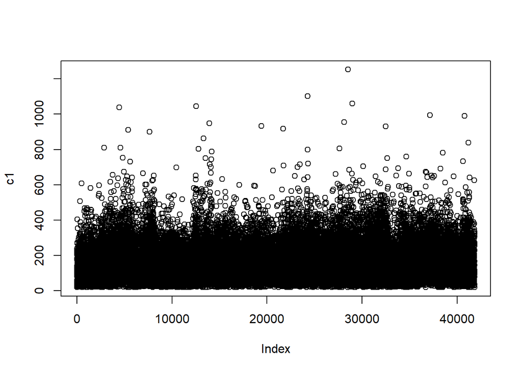

```r
plot(c1)
```

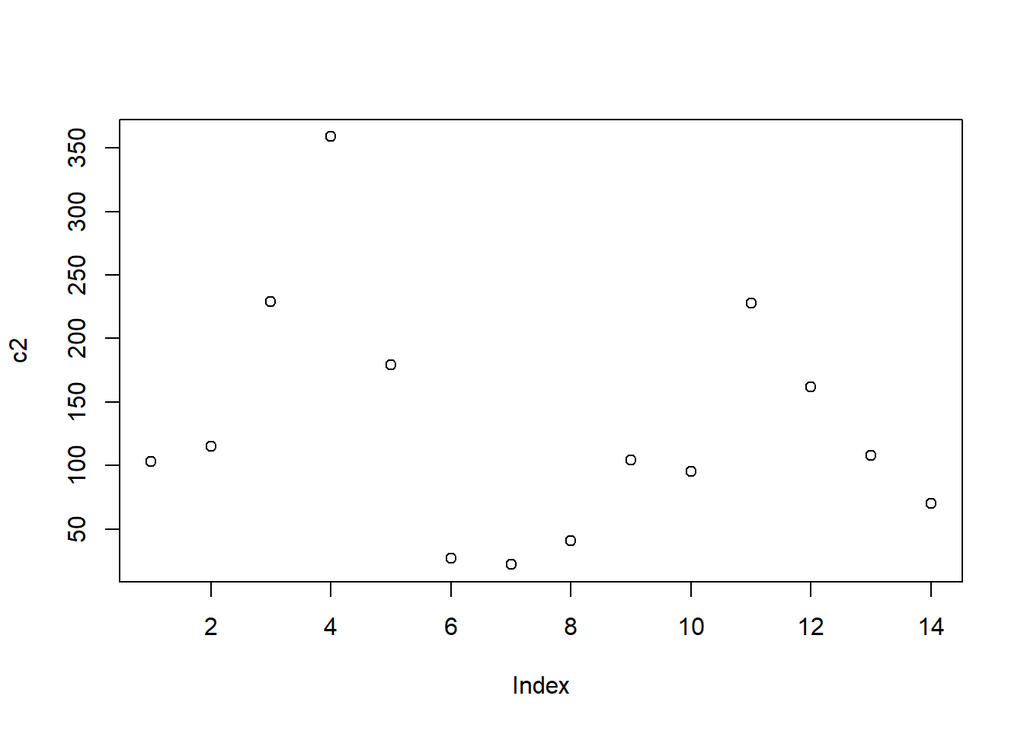

```r
plot(c2)
```

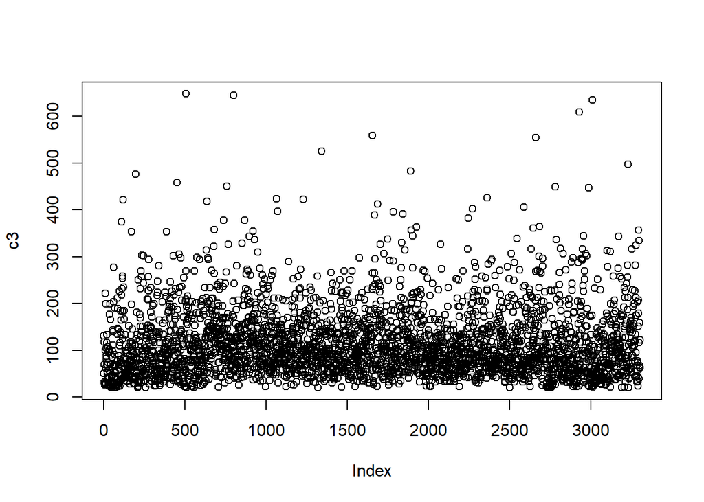

```r
plot(c3)
```

III

Finally, I want to analyze the relationship between original publcation date and the corpus publication date. We are sure that the corpus publication date is later than the original publication date, but how late?

```r
x<-na.omit(Subset$original_publication_date)
y<-na.omit(Subset$corpus_edition_date)
head(x)
```

```
## [1] -320 -320 -320 -320 -320 -320
```

```r
head(y)
```

```
## [1] 1991 1991 1991 1991 1991 1991
```

```r
mean(x)
```

```
## [1] -320
```

```r
mean(y)
```

```
## [1] 1991
```

I suspect that every date in x is -320 and in y is 1991. Let us test.

```r
check_x=TRUE
for (i in 1:length(x)){
  x[i]!=-320
  check_x==FALSE
}
check_y=TRUE
for (i in 1:length(y)){
  y[i]!=-1991
  check_y==FALSE
}
check_x
```

```
## [1] TRUE
```

```r
check_y
```

```
## [1] TRUE
```